# Federal Fiscal Data

analysis

Author

Kennedy Jokonya

Published

September 7, 2026

This is the first post in a Quarto blog. Welcome!

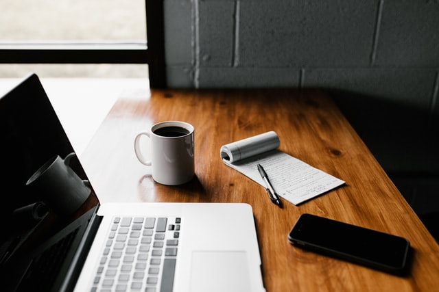

# Introduction

The Federal Government of Canada plays an important role in the nation’s economic activity, accounting for `26.6%` of the nation’s gross domestic product (GDP) in 2009, from consumption and capital formation expenditure alone (Statistics Canada 2018). At this level of importance, the federal government provides information on its financial activity at the end of a period, allowing people to assess the performance of the federal government (Statistics Canada 2018). Given that the data is made public and freely available by Statistics Canada (2024), there is an opportunity to assess how well the federal government has done on a yearly basis through many research ideas using the data. Thus, we will look at an example fiscal data set, describe its variables, and suggest research use cases that can be done.

The federal government uses an internationally accepted method of reporting fiscal data called **government finance statistics (GFS)**, which is a compilation of reported financial information from government activities (Statistics Canada 2018). GFS is a financial reporting method used by many other sovereign countries that allows for comparisons with other nations (Statistics Canada 2018). Through GFS, reporting on the final economic activity of a period, the information is collected from reports of financial activity from government corporations and the transfers and expenditures of the federal, provincial, territorial, local and Aboriginal governments (Statistics Canada 2018).

This results in four reported financial statements that hold the fiscal data;

- the statement of operations,
- the statement of other economic flows,
- the statement of financial position / balance sheet, and
- the statement of sources and uses of cash.

With this, we can retrieve our example fiscal data set from Statistics Canada (2024). This example focuses on two of the reported financial statements: the statement of operations and the statement of financial position from 2009 to 2024.

## Statement of Operations

Statistics Canada (2018)’s definition of the statement of operations is: “summarises the transactions in revenue, expense, net investment in non-financial assets, net acquisition of financial assets and net incurrence of liabilities”. This gives us the general view of revenues and expenses, whose difference results in the net operating balance.

Revenue consists of: taxes on income, profits, capital gains, payroll, property, goods and services, international transactions and other tax bases, social contributions, grants from other levels of government, property income such as interest on loans and distributed income of government business enterprises and some other types of revenue. (Statistics Canada 2018)

Expenses consist of: compensation paid to employees, purchases of goods and services, subsidies, interest on public debt, social benefits paid, consumption of fixed capital and some other types of expenses. (Statistics Canada 2018)

| Variable | Description |
| --- | --- |
| Net operating balance | “is a summary measure of the ongoing sustainability of the government operations. Net operating balance equals total revenues less total expenses.” (Statistics Canada 2024) |
| Revenue | “refers to the gross inflow of economic benefits or service potential during the reporting period when those inflows result in an increase in equity, other than increases relating to contributions fro… |
| Taxes | “compulsory, unrequited amounts receivable by government units from individual institutional units.” (Statistics Canada 2014) Includes: taxes on income, profits and capital gains, taxes on payroll and… |
| Taxes on income, profits and capital gains | “are levied on the actual or presumptive net income of individuals, on the profits of corporations and enterprises, and on capital gains, whether realized or not, on land, securities, and other assets… |
| Taxes on payroll and workforce | Tax income received from taxes on employment wages and salaries. “Taxes on payroll and workforce are not of major importance in Canada, in part because they provide a disincentive for employment.” (St… |
| Taxes on property | “Tax income received from taxes on property owned, are most significant for local government administrations.” (Statistics Canada 2018) Includes: recurrent taxes on immovable property (land, buildings… |
| Taxes on goods and services | “taxes that become payable as a result of the production, sale, transfer, leasing, or delivery of goods and rendering of services, or as a result of their use for own consumption, or own capital forma… |
| Other taxes | Includes: taxes on international trade and transactions consist mainly of Customs and other import duties. (Statistics Canada 2018) |
| Social contributions | “Social contributions are actual or imputed revenue receivable by social insurance schemes to make provision for social insurance benefits payable. Social contributions differ from taxes in that the c… |
| Grants, revenue | “Grants are transfers receivable by government units from other resident or non-resident government units or international organizations, and that do not meet the definition of a tax, subsidy or socia… |
| Other revenue | “Other revenue represents all revenue receivable excluding taxes, social contributions and grants.” (Statistics Canada 2014) Can include: property income such as interest income, royalties, dividends,… |
| Property income | Under other revenue, consists of interest income, royalties, dividends, and remitted profits of government business enterprises of property. (Statistics Canada 2014) |
| Sales of goods and services | Under other revenue, consists of revenue received from the sale of goods and services from government businesses |
| Fines, penalties and forfeits | Under other revenue, consists of revenue received from fines, penalties and forfeits |
| Voluntary transfers other than grants | Under other revenue, consists of revenue received from voluntary transfers other than grants |
| Miscellaneous revenue | Under other revenue, consists of auto insurance premiums, drug plan premiums and revenue not elsewhere classified. (Statistics Canada 2024) |
| Expense | “refers to the decrease in economic benefits or service potential, during the reporting period, in the form of outflows or consumption of assets or incurrence of liabilities that result in decreases i… |
| Compensation of employees | “Compensation of employees is the total remuneration, in cash or in kind, payable to a government employee in return for work done during the accounting period, except for work connected with own acco… |
| Use of goods and services | “This category consists of goods and services used for the production of market and nonmarket goods and services—except for own-account capital formation—plus goods purchased for resale less the net c… |
| Consumption of fixed capital | “Consumption of fixed capital is the decline, during the course of an accounting period, in the current value of the stock of fixed assets owned and used by a general government unit as a result of ph… |
| Interest expense | “Interest is payable by units that incur liabilities by borrowing funds from another unit. Interest is the expense that the debtor unit incurs for the use of the principal outstanding, which represent… |
| Subsidies | “Subsidies are current unrequited transfers that government units make to enterprises on the basis of the level of their production activities or the quantities or values of the goods or services they… |
| Grants, expense | Under expenses, consists of grants paid to others |
| Social benefits | “Social benefits are current transfers, in cash or in kind, receivable by households intended to provide for the needs that arise from social risks, such as sickness, unemployment, retirement, housing… |
| Other expense | “Other expense is a broad category that includes government expenses other than those listed above. Generally these types of expenses are incurred by government business enterprises.”(Statistics Canad… |

## Statement of Financial Position

Statistics Canada (2024)’s definition of the statement of financial position/balance sheet is: “records the stocks of assets, liabilities, and the net worth for each accounting period”. That being, the total value of the assets always equals the total value of the liabilities plus net worth (Statistics Canada 2018).

Assets consist of: Nonfinancial assets, Financial assets, Currency and deposits assets, Debt securities assets, Loans assets, Equity and investment fund shares assets, Insurance and pension assets, Other accounts receivable. (Statistics Canada 2018)

Liabilities consist of: Currency and deposits liabilities, Debt securities liabilities, Loans liabilities, Equity and investment fund shares liabilities, Insurance and pension and standardized guarantee schemes liabilities, Other accounts payable, Monetary gold and special drawing rights (SDR) liabilities. (Statistics Canada 2018)

| Variable | Description |
| --- | --- |
| Net worth | “is defined as the total assets less total liabilities and is an important measure for assessing the sustainability of fiscal activities. The balance sheet components include domestic and foreign coun… |
| Net financial worth | “The net financial worth position equals total stock of financial assets minus liabilities.” (Statistics Canada 2024) |
| Nonfinancial assets | “refers to assets that are produced (e.g. machinery and equipment) or non-produced (e.g. land and natural resources). These assets represent the produced and natural capital that companies use to gene… |
| Financial assets | “refers to all financial claims, shares or other equity in corporations plus gold bullion held by monetary authorities as a reserve asset.” (Statistics Canada 2024) |
| Currency and deposits, assets | “This represents the net acquisition of currency and deposits by government units within a given accounting period. For domestic currency this represents the change in the stock of currency and deposi… |
| Debt securities, assets | “Debt securities are negotiable financial instruments serving as evidence of a debt and for which there normally exist a schedule of interest payments and principal repayment” (Statistics Canada 2014) |
| Loans, assets | “A loan is a financial instrument that is created when a creditor lends funds directly to a debtor. If a loan is tradable, it is reclassified to debt securities.” Statistics Canada (2014) |
| Equity and investment fund shares, assets | “Equity and investment fund shares have the distinguishing feature that the holders own a residual claim on the assets of the unit that issued the instrument. In contrast to debt securities, equity do… |
| Insurance and pension, assets | “This category consists of nonlife insurance technical reserves, life insurance and annuities entitlements, pension entitlements, and claims of pension funds on pension manager. These represent assets… |
| Other accounts receivable | “This represents the value of trade credit and advances and miscellaneous items that either need to be paid or are due to be received by public sector units.” (Statistics Canada 2014) |
| Liabilities | “refers to the present obligations of the entity arising from past events, the settlement of which is expected to result in an outflow from the entity of resources embodying economic benefits or servi… |
| Currency and deposits, liabilities | Currency and deposits owing to others. |
| Debt securities, liabilities | Debt securities owing to others. |
| Loans, liabilities | Loans owing to others. |
| Insurance, pension and standardized guarantee schemes, liabilities | “This category consists of nonlife insurance technical reserves, life insurance and annuities entitlements, pension entitlements, claims of pension funds on pension manager, and provision for calls un… |
| Other accounts payable | Amounts owing to others. |
| Monetary gold and special drawing rights (SDR), liabilities | “Monetary gold is gold to which the monetary authorities have title and is held as a reserve asset. Special drawing rights (SDRs) are international reserve assets created by the International Monetary… |

# Time-Series Analysis of Federal Net Worth

One research use case with federal fiscal data is time-series analysis. This research method takes advantage of the yearly interval of our data, allowing us to see the yearly value of federal net worth.

Time-Series Analysis is a method of research that looks at our available data over periods of time. That is, in this example, our time series data shows us the yearly value of the federal government’s net worth from 2009 to 2024. With this, we can start looking into this data and find anything noteworthy.

### Observed Federal Net Worth

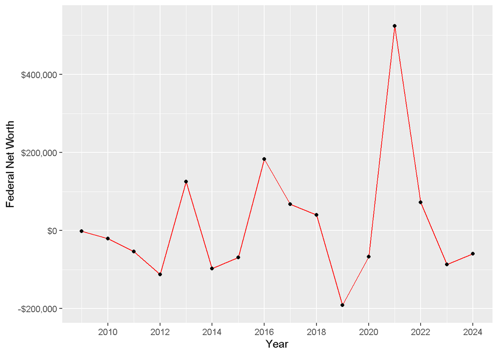

Figure 1: Observed Federal Net Worth From 2009 to 2024. Note that these are raw figures that have not been standardised to the base of any year.

At first glance, we can see the federal net worth year over year mostly fluctuates between -$200,000 and $200,000, with 2021 being a peak outlier reaching $524035. From this, we can already infer that something caused the massive rise in net worth between 2020 and 2021. Likely connected with the COVID-19 pandemic or a specific policy. 2013 and 2016 have peaks above zero, which is another area of interest to look into, and 2019 has the lowest trough, showing another time to look into.

Figure 1 shows the observed movement of federal net worth on a yearly basis, which revealed four areas to look into to find the effect of an event or policy on net worth. However, we can see a trend of fluctuations, but it’s unclear whether it is increasing or decreasing over time. We can overcome this by transforming and smoothing the data to plot and see the general direction of the trend using a method called a simple moving average (SMA).

### Trend of Federal Net Worth

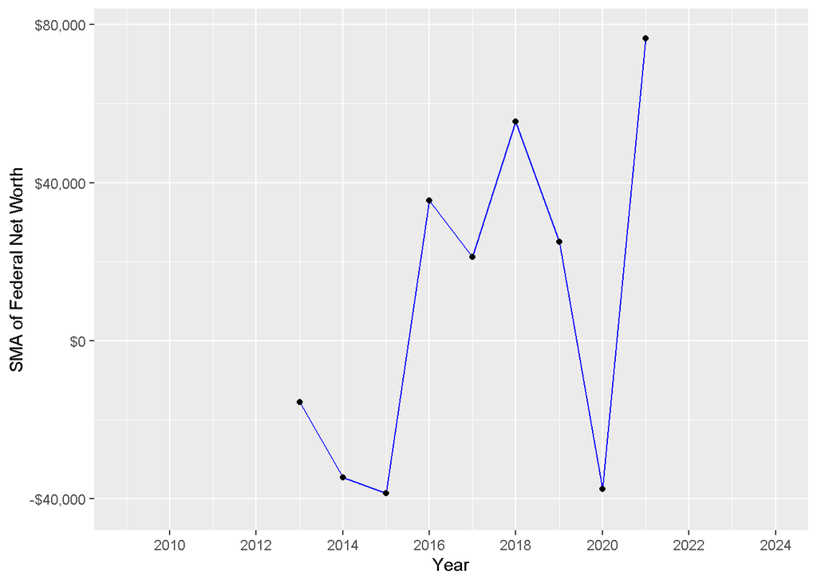

Figure 2: Trend of Federal Net Worth From 2009 to 2024.

By smoothing the data, we get Figure 2, which shows the trend of federal net worth with a positive upward trend over time. This can be a result of multiple federal decisions made yearly, causing the federal government to increase their net worth.

From here, we can pick one or more of the things we have discovered to look further into, and even formulate a research question to answer, such as how the COVID-19 pandemic affected net worth. Find policies that were implemented in years of interest, such as 2013, 2016 and 2019, to see if they are related to net worth and use the data to explain their effect. Find the decisions made public by the federal government that are causing the increasing trend, and evaluate whether this is a net positive or negative by its sustainability. Additionally, we can try to predict the 2025 net worth value using our data by building forecasting models and getting an estimate. Forecasting might be an interesting way to go, as this can reveal whether decisions made are showing positive or negative changes.

# Conclusion

All in all, we learnt that the federal government of Canada makes its fiscal data public for use such as research. Delivered using a trusted method of ensuring accurate data through GFS. This fiscal data is presented as financial data, whose variables we have described and understood. We then picked one variable of interest for an example of doing research, which was evaluating the federal government’s net worth value on a yearly basis through time-series analysis. That showed multiple points of interest for further research and an upward trend. Given this, the opportunity for research using federal fiscal data has endless directions to take for evaluating the federal government’s performance.

# References

Statistics Canada. 2014. “Overview of the Canadian Government Finance Statistics.” 13-605-X. Statistics Canada. https://www150.statcan.gc.ca/n1/pub/13-605-x/2014005/article/14088-eng.pdf.

———. 2018. “Chapter 9 Government Finance Statistics.” In *User Guide: Canadian System of Macroeconomic Accounts*. 13-606-G. Statistics Canada. https://www150.statcan.gc.ca/n1/pub/13-606-g/2016001/article/14624-eng.htm.

———. 2021. “Dictionary, Census of Population, 2021 — Complete a to z Index.” Statistics Canada. https://www12.statcan.gc.ca/census-recensement/2021/ref/dict/az/index-eng.cfm.

———. 2024. “Table 10-10-0147-01 Canadian Government Finance Statistics (CGFS), Statement of Operations and Balance Sheet for Consolidated Governments (x 1,000,000) [Data Set].” Statistics Canada. https://doi.org/10.25318/1010014701-eng.

World Bank. 2026. “Taxes on Income, Profits and Capital Gains (% of Total Taxes) — GC.TAX.YPKG.ZS.” World Bank DataBank. https://databank.worldbank.org/metadataglossary/jobs/series/GC.TAX.YPKG.ZS.